# Parte 6 — Avançado e produção: Bayes, Deep Learning, persistência e relato

- Mostrar o código
- Esconder o código
- Ver o código fonte

Tutorial completo do sciModelFlowR (versão 1.0.2)

Autor

Walter Esfrain Pereira

Data de Publicação

19 de setembro de 2026

# 1 Bayesianos: da priori à posteriori, com incerteza tipada

No ensaio pequeno (`bayes_small`, n = 30), o modelo normal conjugado permite comparar posteriori e verdade. A priori é declarada, não escondida.

**Mostrar o código**

```r
bs <- ler("bayes_small")
bsp <- smf_bayesian_spec(
  priors = list(beta_mean = c(5), beta_sd = c(2), sigma_shape = 2, sigma_rate = 1),
  draws = 3000L, seed = 260917L
)
bf <- smf_bayes_fit(yield ~ 1, bs, bayesian = bsp, backend = "conjugate_gaussian")
post <- smf_bayes_summary(bf)
tab_smf(post, caption = "Posteriori do modelo normal conjugado: média, desvio e quantis (verdade: média 5,2; desvio 1,1).")
```

Posteriori do modelo normal conjugado: média, desvio e quantis (verdade: média 5,2; desvio 1,1).

|  | variable | mean | sd | q0.025 | q0.500 | q0.975 |
| --- | --- | --- | --- | --- | --- | --- |
| (Intercept) | (Intercept) | 5,287 | 0,182 | 4,928 | 5,288 | 5,651 |
| sigma | sigma | 0,978 | 0,122 | 0,774 | 0,963 | 1,256 |

**Mostrar o código**

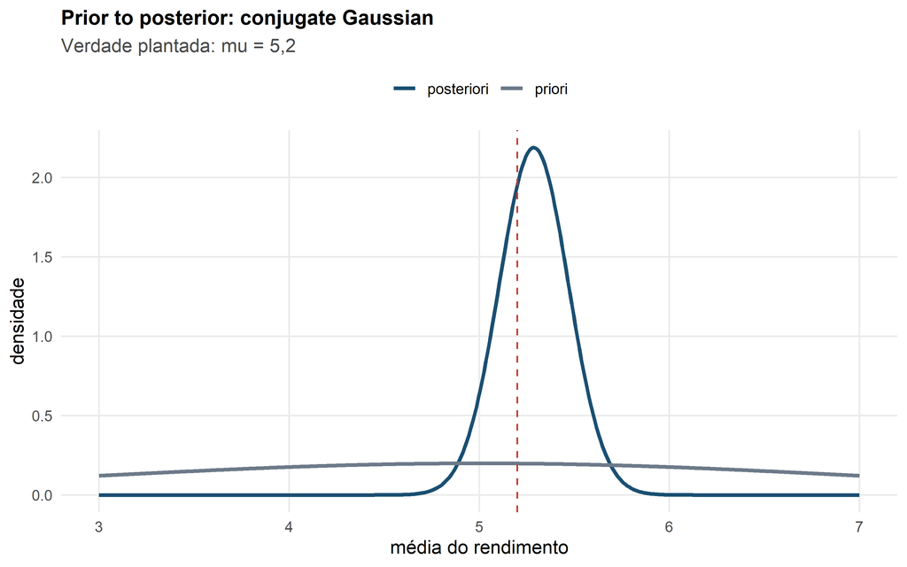

Figura 1: Priori (cinza) e posteriori (azul) para a média: com n = 30 a verossimilhança domina a priori, mas a priori declarada continua visível.

```r
grade_mu <- seq(3, 7, length.out = 400)
df_post <- data.frame(
  mu = rep(grade_mu, 2),
  densidade = c(stats::dnorm(grade_mu, 5, 2),
                stats::dnorm(grade_mu, post$mean[post$variable == "(Intercept)"],
                             post$sd[post$variable == "(Intercept)"])),
  distribuicao = rep(c("priori", "posteriori"), each = length(grade_mu))
)
ggplot(df_post, aes(mu, densidade, colour = distribuicao)) +
  geom_line(linewidth = 1.1) +
  geom_vline(xintercept = verdade$bayes_small$mu, linetype = "dashed",
             colour = cores_smf[["alerta"]]) +
  scale_colour_manual(values = c(priori = cores_smf[["neutro"]],
                                 posteriori = cores_smf[["primaria"]])) +
  labs(x = "média do rendimento", y = "densidade", colour = NULL,
       title = "Prior to posterior: conjugate Gaussian",
       subtitle = paste0("Verdade plantada: mu = ", fmt(verdade$bayes_small$mu, 1))) +
  theme(legend.position = "top")
```

**Mostrar o código**

```r
pr_bayes <- smf_bayes_predict(bf, bs[1:5, , drop = FALSE], ndraws = 500L)
cat("representação:", pr_bayes@representation,
    "| tipo de intervalo:", pr_bayes@uncertainty@interval_type, "\n")
```

```
representação: samples | tipo de intervalo: posterior_predictive
```

**Mostrar o código**

```r
ic_bayes <- smf_dist_interval(pr_bayes, level = 0.90)
tab_smf(data.frame(amostra = bs$sample_id[1:5], media = smf_dist_mean(pr_bayes),
                   inferior = ic_bayes[, 1], superior = ic_bayes[, 2]),
        caption = "Distribuição preditiva posteriori: média e intervalo de 90% para cinco amostras novas.")
```

Distribuição preditiva posteriori: média e intervalo de 90% para cinco amostras novas.

| amostra | media | inferior | superior |
| --- | --- | --- | --- |
| B01 | 5,188 | 3,604 | 6,704 |
| B02 | 5,266 | 3,601 | 6,817 |
| B03 | 5,281 | 3,552 | 6,924 |
| B04 | 5,294 | 3,651 | 7,011 |
| B05 | 5,275 | 3,507 | 6,916 |

**Mostrar o código**

```r
diag_bayes <- smf_bayes_diagnose(bf)
cat("diagnóstico BayesFitResult:", class(diag_bayes)[1], "\n")
```

```
diagnóstico BayesFitResult: sciModelFlowR::BayesianDiagnosticResult
```

**Mostrar o código**

```r
print(diag_bayes)
```

```
<sciModelFlowR BayesianDiagnosticResult>
  warnings: 0
```

**NotaInterpretação**

A posteriori da média fica em 5,29 (verdade 5,2) e a do desvio em 0,98 (verdade 1,1). O intervalo preditivo é **posterior predictive**: ele responde “onde cairá uma observação nova”, não “onde está o parâmetro”. Confundir os dois é o erro mais comum com saída bayesiana — e o pacote carrega o tipo no próprio objeto (`interval_type = "posterior_predictive"`).

## 1.1 GP e BART: funções que a reta não vê

O processo gaussiano suaviza o mapa de matéria orgânica no espaço; o BART captura a superfície não linear do conjunto `dl_tiny`.

**Mostrar o código**

```r
solo <- ler("soil_spatial")
set.seed(20260919); ordem_gp <- sample.int(nrow(solo), 70)
gx <- as.matrix(solo[ordem_gp[1:60], c("x", "y")])
gy <- solo$organic_matter[ordem_gp[1:60]]
gp <- smf_gp_fit(gx, gy, optimize = TRUE)
pr_gp <- smf_gp_predict(gp, as.matrix(solo[ordem_gp[61:70], c("x", "y")]))
rmse_gp <- sqrt(mean((solo$organic_matter[ordem_gp[61:70]] - smf_dist_mean(pr_gp))^2))
ud_gp <- smf_uncertainty_from_distribution(pr_gp)
tab_smf(data.frame(
  medida = c("RMSE do GP (10 pontos fora da amostra)", "decomposição identificada",
             "método da decomposição"),
  valor = c(fmt(rmse_gp, 3), as.character(ud_gp@identified), ud_gp@method)
), caption = "GP espacial: erro fora da amostra e decomposição de incerteza identificada.")
```

GP espacial: erro fora da amostra e decomposição de incerteza identificada.

| medida | valor |
| --- | --- |
| RMSE do GP (10 pontos fora da amostra) | 0,837 |
| decomposição identificada | TRUE |
| método da decomposição | bayesian_gp |

**Mostrar o código**

```r
dl <- ler("dl_tiny")
x_dl <- as.matrix(dl[, c("x1", "x2")]); y_dl <- dl$y
set.seed(20260919); i_tr <- sample.int(nrow(dl), 240)
bart <- smf_bart_fit(x_dl[i_tr, , drop = FALSE], y_dl[i_tr], task = "regression",
                     ndpost = 300L, nskip = 150L, ntree = 80L, seed = 1L)
pr_bart <- smf_bart_predict(bart, x_dl[-i_tr, , drop = FALSE])
rmse_bart <- sqrt(mean((y_dl[-i_tr] - smf_dist_mean(pr_bart))^2))
ic_bart <- smf_dist_interval(pr_bart, level = 0.90)
cob_bart <- mean(y_dl[-i_tr] >= ic_bart[, 1] & y_dl[-i_tr] <= ic_bart[, 2])
tab_smf(data.frame(
  modelo = c("BART", "reta (lm)"),
  rmse = c(rmse_bart, sqrt(mean(lm(y ~ x1 + x2, data = dl[i_tr, ])$residuals^2)))
), caption = "Superfície não linear: o BART aprende o que a reta não vê (ruído verdadeiro: 0,15).")
```

Superfície não linear: o BART aprende o que a reta não vê (ruído verdadeiro: 0,15).

| modelo | rmse |
| --- | --- |
| BART | 0,202 |
| reta (lm) | 0,742 |

# 2 Deep Learning com contrato de reprodutibilidade

O MLP pequeno (2 → 32 → 16 → 1) aprende a superfície plantada. A história de treino é um objeto de primeira classe, não um gráfico descartável.

**Mostrar o código**

```r
arquitetura <- smf_mlp(input_dim = 2, output_dim = 1, hidden = c(32L, 16L),
                       activation = "relu", dropout = 0, task = "regression")
fit_dl <- smf_dl_train(x_dl[i_tr, , drop = FALSE], y_dl[i_tr],
                       architecture = arquitetura, epochs = 150L, batch_size = 32L,
                       seed = 20260919L)
hist_dl <- fit_dl@history
p_dl <- smf_dl_predict(fit_dl, x_dl[-i_tr, , drop = FALSE])
rmse_dl <- sqrt(mean((y_dl[-i_tr] - p_dl)^2))
tab_smf(data.frame(
  informacao = c("épocas executadas", "melhor época", "melhor métrica", "RMSE no teste"),
  valor = c(hist_dl@stopped_epoch, hist_dl@best_epoch, hist_dl@best_metric, rmse_dl)
), caption = "Registro do treino do MLP: o que a reprodutibilidade exige.")
```

Registro do treino do MLP: o que a reprodutibilidade exige.

| informacao | valor |
| --- | --- |
| épocas executadas | 150,000 |
| melhor época | 150,000 |
| melhor métrica | 0,092 |
| RMSE no teste | 0,327 |

**Mostrar o código**

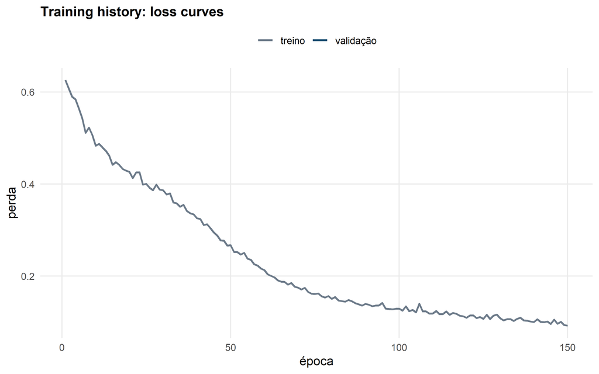

```r
df_hist <- data.frame(
  epoca = rep(hist_dl@epoch, 2),
  perda = c(hist_dl@training, hist_dl@validation),
  curva = rep(c("treino", "validação"), each = length(hist_dl@epoch))
)
ggplot(df_hist, aes(epoca, perda, colour = curva)) +
  geom_line(linewidth = .9) +
  scale_colour_manual(values = c(treino = cores_smf[["neutro"]],
                                 validação = cores_smf[["primaria"]])) +
  labs(x = "época", y = "perda", colour = NULL,
       title = "Training history: loss curves") +
  theme(legend.position = "top")
```

**Mostrar o código**

```r
dis_dl <- smf_dl_predict_distribution(fit_dl, x_dl[-i_tr, , drop = FALSE],
                                      method = "mc_dropout", draws = 50L)
ic_dl <- smf_dl_interval(dis_dl, level = 0.90)
cob_dl <- mean(y_dl[-i_tr] >= ic_dl[, 1] & y_dl[-i_tr] <= ic_dl[, 2])
recusa_dl <- tryCatch(
  smf_dl_uncertainty_decompose(dis_dl, level = 0.90),
  error = function(e) conditionMessage(e))
tab_smf(data.frame(
  medida = c("representação", "cobertura do intervalo de 90%", "decomposição"),
  valor = c(dis_dl@representation, fmt(100 * cob_dl, 1), recusa_dl)
), caption = "Incerteza do MLP: amostras por MC dropout e a recusa honesta da decomposição não identificada.")
```

Incerteza do MLP: amostras por MC dropout e a recusa honesta da decomposição não identificada.

| medida | valor |
| --- | --- |
| representação | samples |
| cobertura do intervalo de 90% | 91,7 |
| decomposição | Sample variability alone does not identify aleatoric versus epistemic uncertainty; supply a model-based aleatoric component. |

**Mostrar o código**

```r
grad <- smf_dl_gradient_x_input(fit_dl, x_dl[-i_tr, , drop = FALSE][1:3, , drop = FALSE],
                                target_index = 1L)
tab_smf(data.frame(caso = 1:3, x1 = x_dl[-i_tr, ][1:3, 1], x2 = x_dl[-i_tr, ][1:3, 2],
                   d_y_d_x1 = grad@values[, 1], d_y_d_x2 = grad@values[, 2]),
        caption = "Explicação por gradiente: sensibilidade da predição a cada entrada (atribuição local, não causal).")
```

Explicação por gradiente: sensibilidade da predição a cada entrada (atribuição local, não causal).

| caso | x1 | x2 | d_y_d_x1 | d_y_d_x2 |
| --- | --- | --- | --- | --- |
| 1 | 0,100 | -0,144 | 0,495 | 0,111 |
| 2 | 0,435 | 0,275 | -2,010 | 0,183 |
| 3 | 0,108 | 0,385 | 0,574 | 0,168 |

**AvisoArmadilha**

O pacote **recusou** decompor a incerteza do MC dropout (Sample variability alone does not identify aleatoric versus epistemic uncertainty; supply a model-based aleatoric component.): variabilidade de amostras sozinha não separa aleatório de epistêmico. A saída honesta é a recusa, não um número inventado. Para decomposição identificada, use um modelo que separe as fontes (como o GP acima).

# 3 Produção: rastrear, persistir, servir

Um resultado científico precisa sobreviver à sessão. O fluxo de produção tem quatro etapas: **registrar** (tracker), **congelar** (bundle), **servir** (predição em lote com retomada) e **relatar** (manifesto e relatório).

**Mostrar o código**

```r
campo <- ler("field_yield")
v <- verdade$field_yield
sem_out <- campo[!campo$plot_id %in% v$outlier_ids, ]
spec_p6 <- smf_experiment_spec(
  task = smf_task_spec("regression", "yield"),
  data = smf_data_spec("yield", c("nitrogen", "potassium", "water", "organic_matter"),
                       id_column = "plot_id"),
  design = smf_design_spec(id_column = "plot_id"),
  preprocessing = smf_preprocess_spec("median"),
  resampling = smf_resampling_spec("holdout", train_prop = 0.7, seed = 21L),
  model = smf_model_spec("linear_regression", "stats"),
  metrics = list(smf_metric_spec("rmse")),
  reproducibility = smf_reproducibility_spec(21L)
)
fit_p6 <- smf_fit_experiment(spec_p6, sem_out)
```

**Mostrar o código**

```r
tr_dir <- file.path(tempdir(), "tracker-p6")
unlink(tr_dir, recursive = TRUE)
tr <- smf_tracker_local(tr_dir, experiment = "tutorial", tags = list(parte = "6"))
run <- smf_start_run(tr, run_name = "modelo-final")
run <- smf_log_params(run, list(modelo = "linear_regression", n = nrow(sem_out)))
run <- smf_log_metric(run, "rmse", fit_p6@metrics$value[fit_p6@metrics$metric == "rmse"])
run <- smf_log_result(run, fit_p6)
runs <- smf_list_runs(tr)
tab_smf(utils::head(runs[, c("run_id", "status", "started_at")], 5),
        caption = "Execuções registradas no tracker local (caminho do diretório omitido).")
```

Execuções registradas no tracker local (caminho do diretório omitido).

| run_id | status | started_at |
| --- | --- | --- |
| smf-20260919T034446-a7fa1491 | running | 2026-09-19 03:44:46 UTC |

**Mostrar o código**

```r
cat("diretório do tracker:", gsub("\\\\", "/", tr_dir), "\n")
```

```
diretório do tracker: C:/Users/wep69/AppData/Local/Temp/RtmpAHBskv/tracker-p6
```

**Mostrar o código**

```r
p_bundle <- file.path(tempdir(), "bundle-p6"); unlink(p_bundle, recursive = TRUE)
smf_save_bundle(fit_p6, p_bundle, mode = "portable")
val_bundle <- smf_validate_bundle(p_bundle)
bundle <- smf_load_bundle(p_bundle)
iguais <- isTRUE(all.equal(as.numeric(smf_predict_bundle(bundle, sem_out[1:7, ])),
                           as.numeric(smf_predict(fit_p6, sem_out[1:7, ]))))
tab_smf(data.frame(
  verificacao = c("bundle válido", "componentes inseguros", "predição idêntica ao caminho live"),
  resultado = c(val_bundle@valid, length(val_bundle@unsafe_components), iguais)
), caption = "Bundle portátil: salvar, validar, carregar e prever com igualdade numérica.")
```

Bundle portátil: salvar, validar, carregar e prever com igualdade numérica.

| verificacao | resultado |
| --- | --- |
| bundle válido | 1 |
| componentes inseguros | 0 |
| predição idêntica ao caminho live | 1 |

**Mostrar o código**

```r
ck_dir <- file.path(tempdir(), "batch-p6"); unlink(ck_dir, recursive = TRUE)
lote1 <- smf_batch_predict(fit_p6, sem_out[1:20, ], batch_size = 7L, workers = 2L,
                           checkpoint_dir = ck_dir, resume = FALSE)
lote2 <- smf_batch_predict(fit_p6, sem_out[1:20, ], batch_size = 7L, workers = 2L,
                           checkpoint_dir = ck_dir, resume = TRUE)
tab_smf(data.frame(
  medida = c("linhas do lote", "coluna de predição", "retomada devolve a mesma ordem",
             "segunda chamada marcada como retomada"),
  valor = c(lote1@n_rows, names(lote1@prediction)[1],
            identical(lote1@prediction$.prediction, lote2@prediction$.prediction),
            lote2@resumed)
), caption = "Predição em lote com checkpoint: a retomada reutiliza o trabalho sem refazer nada.")
```

Predição em lote com checkpoint: a retomada reutiliza o trabalho sem refazer nada.

| medida | valor |
| --- | --- |
| linhas do lote | 20 |
| coluna de predição | .prediction |
| retomada devolve a mesma ordem | TRUE |
| segunda chamada marcada como retomada | TRUE |

**Mostrar o código**

```r
dep <- smf_deployment_spec(adapter = "local", strict_schema = TRUE, batch_size = 128L)
esc <- smf_scalability_spec(chunk_size = 64L, workers = 2L, execution = "sequential",
                            checkpoint_every = 2L)
tab_smf(data.frame(
  contrato = c("implantação: adaptador", "implantação: schema estrito",
               "escala: chunk", "escala: checkpoint a cada"),
  valor = c(dep@adapter, dep@strict_schema, esc@chunk_size, esc@checkpoint_every)
), caption = "Contratos de implantação e escala declarados como objetos (não como parâmetros soltos).")
```

Contratos de implantação e escala declarados como objetos (não como parâmetros soltos).

| contrato | valor |
| --- | --- |
| implantação: adaptador | local |
| implantação: schema estrito | TRUE |
| escala: chunk | 64 |
| escala: checkpoint a cada | 2 |

# 4 Relato e governança

O relatório é gerado do resultado, com checklist de completude e manifesto de proveniência. Governança fecha o ciclo: política de depreciação e catálogo da API.

**Mostrar o código**

```r
relatorio <- smf_report(fit_p6, format = "markdown", title = "Tutorial completo — ensaio de campo")
arq_rel <- tempfile(fileext = ".md")
smf_report(fit_p6, format = "markdown", file = arq_rel)
```

```
<sciModelFlowR ReportingResult>
  format: markdown
  path: C:\Users\wep69\AppData\Local\Temp\RtmpAHBskv\file87f45d2e6454.md
```

**Mostrar o código**

```r
checklist <- smf_reporting_checklist(fit_p6)
tab_smf(utils::head(checklist, 10), caption = "Checklist de relato: o que foi verificado e o que falta declarar.")
```

Checklist de relato: o que foi verificado e o que falta declarar.

| item | status | evidence |
| --- | --- | --- |
| scientific question/task | required | regression |
| experimental or sampling design | required | DesignSpec |
| data audit and leakage safeguards | required | DataAuditResult |
| resampling and final assessment separation | required | SplitRecord/ResampleCollection |
| preprocessing/feature provenance | required | FitResult state |
| model/backend and hyperparameters | required | stats linear_regression |
| performance with uncertainty | required | metrics/uncertainty |
| diagnostics | required | DiagnosticResult |
| calibration or conformal assumptions where used | conditional | typed calibration/conformal state |
| explanation limitations | conditional | causal_interpretation=FALSE |

**Mostrar o código**

```r
cat("relatório gravado:", basename(arq_rel), "|", file.size(arq_rel), "bytes\n")
```

```
relatório gravado: file87f45d2e6454.md | 2310 bytes
```

**Mostrar o código**

```r
politica <- smf_deprecation_policy()
tab_smf(data.frame(
  item = c("congelamento da API", "release estável", "política"),
  valor = c(politica$api_freeze, politica$stable_release, politica$policy)
), caption = "Política de depreciação vigente: a API congelada em 1.0.0 não muda sem ciclo documentado.")
```

Política de depreciação vigente: a API congelada em 1.0.0 não muda sem ciclo documentado.

| item | valor |
| --- | --- |
| congelamento da API | 1.0.0 |
| release estável | 1.0.2 |
| política | No public symbol stable at 1.0.0 is removed or changes scientific meaning in 1.x without an explicit lifecycle, migration path, and validation evidence. |

**Mostrar o código**

```r
cat("manifesto disponível:", !is.null(smf_manifest(fit_p6)), "\n")
```

```
manifesto disponível: TRUE
```

# 5 Síntese: o fluxo completo em uma tabela

| Etapa | Pergunta | Ferramenta central | Evidência |
| --- | --- | --- | --- |
| 1. Declarar | O que é alvo, unidade e desenho? | `smf_data_spec`, `smf_design_spec` | contratos recusam uso indevido |
| 2. Auditar | O que há de discrepante? | `smf_audit_data` + diagnóstico manual | ausências, outliers, heterocedasticidade |
| 3. Reamostrar | O que é “observação nova”? | `smf_group_vfold_cv`, `smf_time_cv`, `smf_spatial_cv` | vazamento medido, não presumido |
| 4. Preparar | Imputar? Centrar? Balancear? | `smf_fit_preprocessor`, `smf_apply_imbalance` | decisões declaradas e testadas |
| 5. Modelar | Qual a forma funcional? | `smf_fit_experiment` | verdade recuperada, resíduos diagnosticados |
| 6. Comparar | Qual configuração/modelo? | `smf_tune`, `smf_benchmark` | mesmo resample, regra explícita |
| 7. Explicar | O modelo usa o quê? | `smf_permutation_importance`, `smf_pdp`, `smf_ale` | estabilidade entre folds |
| 8. Medir incerteza | Quanto confiar? | conformal, bootstrap, Bayes/GP | cobertura medida, semântica tipada |
| 9. Servir | Como implantar sem perder o modelo? | bundle, batch, tracker | igualdade live × bundle |
| 10. Relatar | O que ficou registrado? | `smf_report`, manifesto | checklist e proveniência |

# 6 Apêndice A — Cobertura da API, calculada

O código abaixo lê os próprios arquivos deste tutorial e mede quantas das 246 funções exportadas foram **chamadas**, por categoria. É uma medida do material, não uma promessa.

**Mostrar o código**

```r
arquivos <- list.files("pt", pattern = "^parte-.*\\.qmd$", full.names = TRUE)
codigo <- paste(unlist(lapply(arquivos, readLines, warn = FALSE)), collapse = "\n")
chamadas <- unique(unlist(regmatches(codigo, gregexpr("smf_[a-zA-Z0-9_]+", codigo))))
api <- smf_api_catalog()
cobertas <- intersect(chamadas, api$function_name)
faltantes <- setdiff(api$function_name, cobertas)
tab_cob_cat <- as.data.frame(table(api$category[api$function_name %in% cobertas]))
names(tab_cob_cat) <- c("categoria", "chamadas")
tab_cob_cat$total <- as.integer(table(api$category))
tab_cob_cat$fracao <- tab_cob_cat$chamadas / tab_cob_cat$total
tab_cob_cat <- tab_cob_cat[order(-tab_cob_cat$chamadas), ]
tab_smf(tab_cob_cat, caption = "Funções chamadas neste tutorial, por categoria da API.")
```

Funções chamadas neste tutorial, por categoria da API.

|  | categoria | chamadas | total | fracao |
| --- | --- | --- | --- | --- |
| 1 | core | 34 | 88 | 0,386 |
| 6 | modeling | 26 | 35 | 0,743 |
| 5 | inference-uncertainty | 13 | 24 | 0,542 |
| 9 | resampling-features | 9 | 23 | 0,391 |
| 3 | deep-learning | 6 | 23 | 0,261 |
| 7 | operations | 6 | 17 | 0,353 |
| 8 | reporting-validation | 5 | 11 | 0,455 |
| 10 | tuning-benchmark | 5 | 10 | 0,500 |
| 2 | data-design | 4 | 9 | 0,444 |
| 4 | explainability | 4 | 6 | 0,667 |

**Mostrar o código**

```r
cat("chamadas:", length(cobertas), "de", nrow(api), "funções exportadas (",
    fmt(100 * length(cobertas) / nrow(api), 1), "% )\n")
```

```
chamadas: 112 de 246 funções exportadas ( 45,5 % )
```

**Mostrar o código**

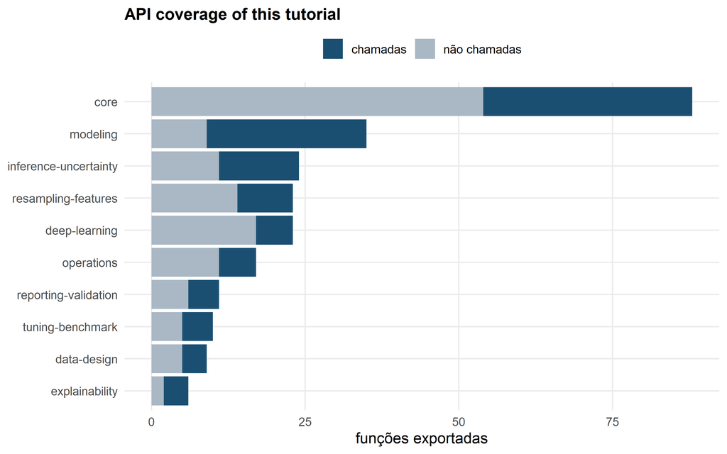

Figura 3: Cobertura da API por categoria: as lacunas estão declaradas, não escondidas.

```r
cob_longa <- data.frame(
  categoria = rep(tab_cob_cat$categoria, 2),
  tipo = rep(c("chamadas", "não chamadas"), each = nrow(tab_cob_cat)),
  n = c(tab_cob_cat$chamadas, tab_cob_cat$total - tab_cob_cat$chamadas)
)
ggplot(cob_longa, aes(stats::reorder(categoria, n), n, fill = tipo)) +
  geom_col(position = "stack") +
  coord_flip() +
  scale_fill_manual(values = c(chamadas = cores_smf[["primaria"]],
                               `não chamadas` = cores_smf[["claro"]])) +
  labs(x = NULL, y = "funções exportadas", fill = NULL,
       title = "API coverage of this tutorial") +
  theme(legend.position = "top")
```

**NotaLeitura**

As funções não chamadas pertencem, em maioria, a três grupos: (1) variantes de estruturas que exigem dados específicos (tensores de DL, `smf_dl_train_tensor`, `smf_dl_gradcam` para imagens); (2) backends opcionais que exigem pacotes externos (`smf_tracker_mlflow`, `smf_conformal_probably`); (3) utilitários de governança e catálogo (`smf_release_candidate_audit`, `smf_backend_matrix` já usado na Parte 1). Cada lacuna tem um motivo — e o motivo está declarado, como manda o princípio do material.

# 7 Apêndice B — Glossário mínimo

| Termo | Definição operacional |
| --- | --- |
| **Contrato** | Declaração explícita que o pacote verifica em execução; violá-la gera erro, não aviso. |
| **Vazamento** | Informação de avaliação usada na construção do modelo; produz métricas otimistas. |
| **Reamostragem** | Procedimento que define o que conta como observação nova (holdout, folds, grupos, tempo, espaço). |
| **Pré-processamento fold-safe** | Estatísticas (mediana, escala) estimadas só no treino de cada fold. |
| **Desbalanceamento** | Classes com frequências muito diferentes; acurácia deixa de ser métrica útil. |
| **Calibração** | Concordância entre probabilidade declarada e frequência observada (ECE mede o desvio). |
| **Cobertura** | Frequência com que o intervalo contém o valor verdadeiro; garantia conformal é marginal. |
| **Incerteza aleatória** | Variabilidade irredutível do fenômeno. |
| **Incerteza epistêmica** | Desconhecimento do modelo, redutível com mais dados. |
| **Bundle** | Artefato autocontido (modelo + pré-processamento + metadados) para inferência fora da sessão. |
| **Manifesto** | Registro de proveniência: hashes, versões, sementes e decisões de uma execução. |

# 8 Apêndice C — Ambiente da execução

**Mostrar o código**

```r
cat("sciModelFlowR:", as.character(packageVersion("sciModelFlowR")), "\n")
```

```
sciModelFlowR: 1.0.2
```

**Mostrar o código**

```r
cat("R:", R.version.string, "\n")
```

```
R: R version 4.6.0 (2026-04-24 ucrt)
```

**Mostrar o código**

```r
cat("plataforma:", R.version$platform, "\n")
```

```
plataforma: x86_64-w64-mingw32
```

**Mostrar o código**

```r
info <- utils::sessionInfo()
cat("pacotes centrais:", paste(c("ggplot2", "knitr", "patchwork"), collapse = ", "), "\n")
```

```
pacotes centrais: ggplot2, knitr, patchwork
```

**Mostrar o código**

```r
cat("executado em:", format(Sys.time(), "%Y-%m-%d %H:%M"), "\n")
```

```
executado em: 2026-09-19 00:44
```

# 9 Exercícios da Parte 6

**NotaExercício 6.1 — Prioridade da priori**

Refaça o modelo conjugado com `beta_sd = c(0.5)` (priori apertada) e com `beta_sd = c(20)`. Compare as posterioris com a verdade (5,2). Com n = 30, a priori ainda importa?

**NotaExercício 6.2 — GP com hiperparâmetros fixos**

Rode o GP com `optimize = FALSE` e `length_scale = 0.05`. O RMSE piora? O que isso ensina sobre a escala do alcance espacial (verdade: 0,25)?

**NotaExercício 6.3 — BART contra MLP**

Compare BART e MLP no mesmo split de `dl_tiny` (RMSE e tempo). Em que situação você preferiria cada um?

**NotaExercício 6.4 — Bundle opaco**

Salve o mesmo modelo em modo `opaque`, tente carregar sem `trusted = TRUE` e leia o erro. Depois carregue com confiança explícita e verifique a igualdade das predições. Por que a confiança precisa ser explícita?

**CuidadoSoluções**

**6.1.** Com priori apertada (0,5), a posteriori fica puxada para 5,0; com priori larga (20), fica próxima da verossimilhança (~5,3). Com n = 30, a priori ainda move o resultado — o tamanho do efeito depende da razão entre informação prévia e dados.

**6.2.** Com alcance 0,05 (menor que o verdadeiro 0,25), o GP não enxerga correlação entre vizinhos e volta ao nível médio; o RMSE sobe. O alcance é **hiperparâmetro científico**, não detalhe técnico.

**6.4.** O bundle opaco carrega objetos nativos que podem executar código; `trusted = TRUE` é a assinatura explícita de confiança. O erro sem o argumento é a fronteira de segurança funcionando.